# EGRMGMT 590.21 Homework 5 (Questions)

## Instructions

- Use R Markdown to complete the exercises in order. Please show both your R code and its corresponding output
- There are 10 exercises in total, each of which is worth 10 points
- One exercise can be potentially solved in multiple ways. The grade is based on the output accuracy, not on performance
- Submit the completed homework in a .html file to Sakai by **6:15pm ET on Thursday, October 17**. Assignments handed in late will lose 10 points each day after the due date
- For more information about R Markdown, please visit the two links in the References/Readings slide in the week 2 deck

## Exercises

### Data Introduction

- Read the .csv file from https://goo.gl/z5P8ce into a dataframe named brand.df. The dataset includes customers’ ratings on nine adjectives for four fictitious consumer electronic device brands: Papa, Romeo, Sierra, and Tango.
- The adjectives rated are Adaptable, Best Value, Cutting Edge, Delightful, Exciting, Friendly, Generous, Helpful, and Intuitive.

### Exercise 1 (10 Points)

- Standardize the ratings data and save the standardized data to a new dataframe named brand.sc
- What are the mean and standard deviation of the standardized ratings by adjective?

```r
brand.df<-read.csv("https://goo.gl/z5P8ce")
str(brand.df)
```

```
## 'data.frame':    3050 obs. of  10 variables:
##  $ Adaptable  : int  6 4 3 4 4 4 5 4 5 5 ...
##  $ BestValue  : int  5 3 2 1 1 3 3 2 4 3 ...
##  $ CuttingEdge: int  4 4 3 4 3 4 5 7 4 5 ...
##  $ Delightful : int  4 2 6 4 3 4 4 5 3 4 ...
##  $ Exciting   : int  3 4 5 5 3 3 6 4 3 5 ...
##  $ Friendly   : int  4 4 5 4 5 4 3 3 4 6 ...
##  $ Generous   : int  5 5 6 5 5 6 5 5 4 4 ...
##  $ Helpful    : int  4 2 4 3 4 2 3 4 3 5 ...
##  $ Intuitive  : int  3 5 3 3 4 4 4 4 3 5 ...
##  $ Brand      : Factor w/ 4 levels "Papa","Romeo",..: 3 2 3 3 3 3 2 3 3 3 ...
```

```r
brand.sc<-scale(brand.df[,-10])
brand.sc<-cbind(brand.sc , brand.df[10])
brand.aggri<-aggregate(.~Brand, data = brand.sc, mean)
brand.aggri
```

```
##    Brand   Adaptable   BestValue CuttingEdge  Delightful   Exciting
## 1   Papa  0.14841080 -0.13393612  -0.5604212 -0.46269229 -0.5077675
## 2  Romeo  0.04996503 -0.03200097  -0.1484920 -0.05263695 -0.1269354
## 3 Sierra -0.08512586  0.02357325   0.2206725  0.12798728  0.1906176
## 4  Tango -0.09833215  0.23277501   0.5849726  0.41299524  0.5349072
##     Friendly    Generous     Helpful  Intuitive
## 1  0.4364509 -0.28429068  0.43548924  0.4754246
## 2  0.1267805 -0.08719489  0.08804295  0.1571494
## 3 -0.1921701  0.11207569 -0.16134273 -0.2063743
## 4 -0.4241198  0.34164467 -0.38693834 -0.5456081
```

```r
brand.standarddev<-aggregate(.~Brand, data = brand.sc, sd)
brand.standarddev
```

```
##    Brand Adaptable BestValue CuttingEdge Delightful  Exciting  Friendly
## 1   Papa 1.0044720 0.9504530   0.9805722  0.9698337 0.9786869 1.0075057
## 2  Romeo 0.9887354 0.9968314   0.9515750  0.9534347 0.9536193 0.9662182
## 3 Sierra 1.0207677 1.0109687   0.9255792  0.9853778 0.9635503 0.9416329
## 4  Tango 0.9225119 1.0042735   0.9403461  0.9976307 0.9053203 0.9995285
##    Generous   Helpful Intuitive
## 1 1.0108670 0.9588744 0.9231676
## 2 0.9743636 0.9803415 0.9594119
## 3 0.9737037 0.9649023 0.9564713
## 4 1.0248567 0.9875055 0.9803450
```

### Exercise 2 (10 Points)

- Use the corrplot() function in the corrplot library to create a correlation matrix plot for the data in brand.sc
- How many dimensions does the plot suggest the adjectives to be reduced to?
- [Hint] Select an appropriate setting for the “order” parameter in corrplot() to derive a clearer visualization by reordering the adjectives

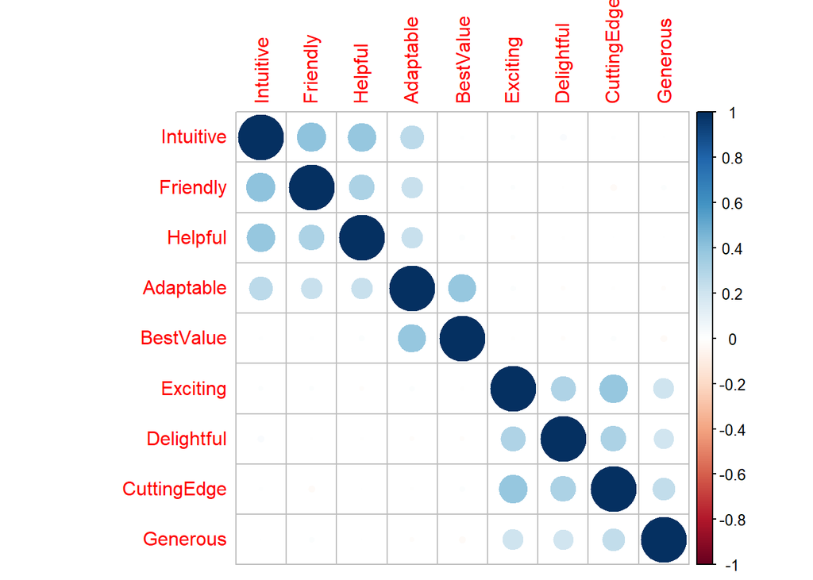

```r
library(gplots)
library(corrplot)
q2<-corrplot(corr=cor(brand.sc[,-10]), order="FPC")
```

```r
q2
```

```
##                Intuitive     Friendly       Helpful    Adaptable
## Intuitive   1.0000000000  0.405189750  0.3861218763  0.267282944
## Friendly    0.4051897501  1.000000000  0.3103062856  0.222823893
## Helpful     0.3861218763  0.310306286  1.0000000000  0.223563804
## Adaptable   0.2672829442  0.222823893  0.2235638040  1.000000000
## BestValue   0.0077104363  0.008599721  0.0194791406  0.383607245
## Exciting    0.0117095162  0.010554156 -0.0114283030  0.013324976
## Delightful  0.0230496068 -0.002969745 -0.0051462069 -0.010457716
## CuttingEdge 0.0083985960 -0.021904660  0.0005238269 -0.005659335
## Generous    0.0005287593  0.013165267  0.0010246712 -0.011203360
##                BestValue     Exciting   Delightful   CuttingEdge
## Intuitive    0.007710436  0.011709516  0.023049607  0.0083985960
## Friendly     0.008599721  0.010554156 -0.002969745 -0.0219046599
## Helpful      0.019479141 -0.011428303 -0.005146207  0.0005238269
## Adaptable    0.383607245  0.013324976 -0.010457716 -0.0056593350
## BestValue    1.000000000 -0.009606121 -0.012199455  0.0146340078
## Exciting    -0.009606121  1.000000000  0.300981148  0.3890504133
## Delightful  -0.012199455  0.300981148  1.000000000  0.3141072449
## CuttingEdge  0.014634008  0.389050413  0.314107245  1.0000000000
## Generous    -0.020746086  0.208949918  0.199048427  0.2486925978
##                  Generous
## Intuitive    0.0005287593
## Friendly     0.0131652672
## Helpful      0.0010246712
## Adaptable   -0.0112033597
## BestValue   -0.0207460862
## Exciting     0.2089499184
## Delightful   0.1990484268
## CuttingEdge  0.2486925978
## Generous     1.0000000000
```

```r
###we should reduce this to 3 dimensions ;this is what we can infer from the graph
```